# Practical Machine Learning Project

Sachi Norman

31 January 2016

## Background

Using devices such as Jawbone Up, Nike FuelBand, and Fitbit it is now possible to collect a large amount of data about personal activity relatively inexpensively. These type of devices are part of the quantified self movement ??? a group of enthusiasts who take measurements about themselves regularly to improve their health, to find patterns in their behavior, or because they are tech geeks. One thing that people regularly do is quantify how much of a particular activity they do, but they rarely quantify how well they do it. In this project, I will use data from accelerometers on the belt, forearm, arm, and dumbell of 6 participants. To identify if they perform barbell lifts correctly or incorrectly in 5 different ways:

1. A - Exactly according to specification
2. B - Throwing the elbows to the front
3. C - Lifting the dumbell only halfway
4. D - Lowering the dumbell only halfway
5. E - Throwing the hips to the front

A machine learning model will be trained on the data set to predict the classe variable based on the activity data.

## Data

The training data for this project are available here:

https://d396qusza40orc.cloudfront.net/predmachlearn/pml-training.csv

The test data are available here:

https://d396qusza40orc.cloudfront.net/predmachlearn/pml-testing.csv

The data for this project come from this source: http://groupware.les.inf.puc-rio.br/har.

libraries requiered

## Loading Data and Partitioning

```r
trainurl <- "https://d396qusza40orc.cloudfront.net/predmachlearn/pml-training.csv"
testurl <- "https://d396qusza40orc.cloudfront.net/predmachlearn/pml-testing.csv"
trainset <- read.csv(url(trainurl),na.strings = c("NA","#DIV/0!",""))
testset <- read.csv(url(testurl),na.strings = c("NA","#DIV/0!",""))

inTrain <- createDataPartition(trainset$classe,p=0.7,list=FALSE)
mytrain <- trainset[inTrain,]
myvalid <- trainset[-inTrain,]
```

## Cleaning the Data

Remove the id column from the dataset

```r
mytrain <- mytrain[c(-1)]
```

Removing variable with near zero variance that can not contribute to explaining the variance in the classe variable from the training and validation sets

```r
nzvT <- nearZeroVar(mytrain,saveMetrics = TRUE)
mytrain <- mytrain[,nzvT$nzv == FALSE]
```

Removing variables with high precentage of NA values more than 65%

```r
mytrain <- mytrain[, colSums(is.na(mytrain)) < nrow(mytrain) * 0.65]
```

Applying the same transformations on the validation and test sets

```r
myvalid <- myvalid[,colnames(mytrain)]
testset <- testset[,colnames(mytrain[,-58])]
```

## Developing a Prediction Model

```r
set.seed(3468)
```

## Predict using Gradient Boosting

```r
fitc <- trainControl(method = "repeatedcv",number = 5,repeats = 1)
gbm1 <- train(classe~.,data=mytrain,method="gbm",trControl=fitc,verbose = FALSE)
gbmpred <- predict(gbm1,newdata=myvalid)
gbmacc <- confusionMatrix(gbmpred,myvalid$classe)
gbmacc
```

```
## Confusion Matrix and Statistics
##
##           Reference
## Prediction    A    B    C    D    E
##          A 1673    0    0    0    0
##          B    0 1138    2    0    0
##          C    0    1 1021    1    0
##          D    1    0    3  961    1
##          E    0    0    0    2 1081
##
## Overall Statistics
##
##                Accuracy : 0.9981
##                  95% CI : (0.9967, 0.9991)
##     No Information Rate : 0.2845
##     P-Value [Acc > NIR] : < 2.2e-16
##
##                   Kappa : 0.9976
##  Mcnemar's Test P-Value : NA
##
## Statistics by Class:
##
##                      Class: A Class: B Class: C Class: D Class: E
## Sensitivity            0.9994   0.9991   0.9951   0.9969   0.9991
## Specificity            1.0000   0.9996   0.9996   0.9990   0.9996
## Pos Pred Value         1.0000   0.9982   0.9980   0.9948   0.9982
## Neg Pred Value         0.9998   0.9998   0.9990   0.9994   0.9998
## Prevalence             0.2845   0.1935   0.1743   0.1638   0.1839
## Detection Rate         0.2843   0.1934   0.1735   0.1633   0.1837
## Detection Prevalence   0.2843   0.1937   0.1738   0.1641   0.1840
## Balanced Accuracy      0.9997   0.9994   0.9974   0.9979   0.9993
```

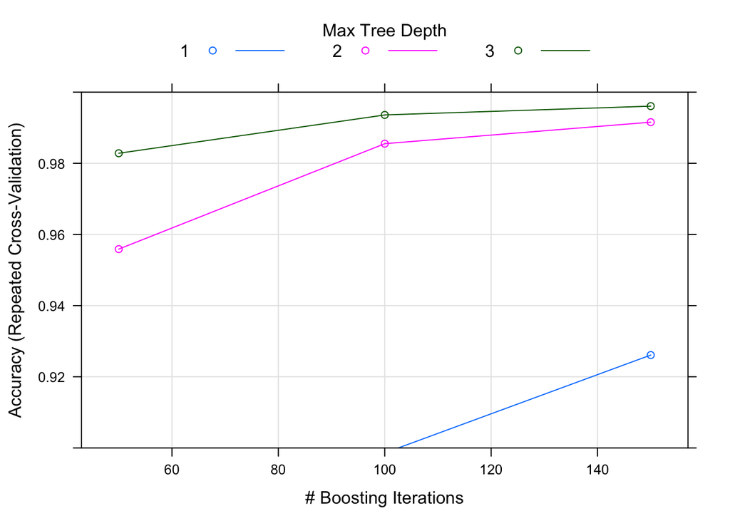

```r
plot(gbm1,ylim = c(0.9,1))
```

## Predict Using Random Forest

```r
RF <- train(classe~.,data=mytrain,method="rf",prox=TRUE,allowParallel=TRUE)
predRF <- predict(RF,myvalid)
cmrf <- confusionMatrix(predRF,myvalid$classe)
```

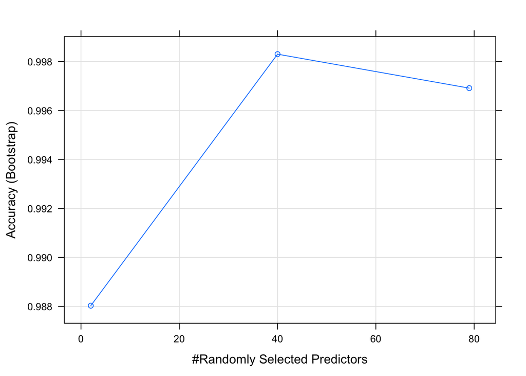

```r
plot(RF)
```

## Predicting Test Data

```r
predtest <- predict(RF,testset)
predtest
```

```
##  [1] B A B A A E D B A A B C B A E E A B B B
## Levels: A B C D E
```